# Titanic Data Analysis using R

Author

Md Ahsanul Islam

Published

October 6, 2024

# 1 Project Setup

Loading required packages:

```r
library(dplyr)
library(ggplot2)
library(RColorBrewer) # for color palette
```

Setting some default behaviors:

```r
theme_set(
    # globally set ggplot2 theme to bw
    theme_bw() +
    theme(
        axis.text = element_text(size = 12),     # axis text size
        axis.title = element_text(size = 14),    # axis title size
        legend.title = element_text(size = 14),  # legend title
        legend.text = element_text(size = 12),   # legend text
        strip.text = element_text(size = 14),    # facet title
        plot.title = element_text(size = 16, hjust = 0.5)  # plot title
        )
    )
options(ggplot2.discrete.fill = brewer.pal(12, "Paired")) # globally set color palette
```

## 1.1 Data Import

**Data description**

- Survival : 0 = No, 1 = Yes
- Pclass : Ticket class (1 = 1st, 2 = 2nd, 3 = 3rd)
- Sex : Sex
- Age : Age
- SibSp : # of siblings / spouses onboard the Titanic
- Parch : # of parents / children onboard the Titanic (Some children travelled only with a nanny, therefore parch=0 for them)
- Ticket : Ticket number
- Fare : Passenger fare
- Cabin : Cabin number
- Embarked : Port of Embarkation (C = Cherbourg, Q = Queenstown, S = Southampton)

```r
titanic <- read.csv("titanic.csv")
```

Inspecting first few rows:

```r
head(titanic)
```

| PassengerId | Survived | Pclass | Name | Sex | Age | SibSp | Parch | Ticket | Fare | Cabin | Embarked |
| --- | --- | --- | --- | --- | --- | --- | --- | --- | --- | --- | --- |
| 1 | 0 | 3 | Braund, Mr. Owen Harris | male | 22 | 1 | 0 | A/5 21171 | 7.2500 |  | S |
| 2 | 1 | 1 | Cumings, Mrs. John Bradley (Florence Briggs Thayer) | female | 38 | 1 | 0 | PC 17599 | 71.2833 | C85 | C |
| 3 | 1 | 3 | Heikkinen, Miss. Laina | female | 26 | 0 | 0 | STON/O2. 3101282 | 7.9250 |  | S |
| 4 | 1 | 1 | Futrelle, Mrs. Jacques Heath (Lily May Peel) | female | 35 | 1 | 0 | 113803 | 53.1000 | C123 | S |
| 5 | 0 | 3 | Allen, Mr. William Henry | male | 35 | 0 | 0 | 373450 | 8.0500 |  | S |
| 6 | 0 | 3 | Moran, Mr. James | male | NA | 0 | 0 | 330877 | 8.4583 |  | Q |

Inspecting the structure of the dataset:

```r
str(titanic)
```

```
'data.frame':   891 obs. of  12 variables:
 $ PassengerId: int  1 2 3 4 5 6 7 8 9 10 ...
 $ Survived   : int  0 1 1 1 0 0 0 0 1 1 ...
 $ Pclass     : int  3 1 3 1 3 3 1 3 3 2 ...
 $ Name       : chr  "Braund, Mr. Owen Harris" "Cumings, Mrs. John Bradley (Florence Briggs Thayer)" "Heikkinen, Miss. Laina" "Futrelle, Mrs. Jacques Heath (Lily May Peel)" ...
 $ Sex        : chr  "male" "female" "female" "female" ...
 $ Age        : num  22 38 26 35 35 NA 54 2 27 14 ...
 $ SibSp      : int  1 1 0 1 0 0 0 3 0 1 ...
 $ Parch      : int  0 0 0 0 0 0 0 1 2 0 ...
 $ Ticket     : chr  "A/5 21171" "PC 17599" "STON/O2. 3101282" "113803" ...
 $ Fare       : num  7.25 71.28 7.92 53.1 8.05 ...
 $ Cabin      : chr  "" "C85" "" "C123" ...
 $ Embarked   : chr  "S" "C" "S" "S" ...
```

Inspect summary of the datset:

```r
summary(titanic)
```

```
  PassengerId       Survived          Pclass          Name
 Min.   :  1.0   Min.   :0.0000   Min.   :1.000   Length:891
 1st Qu.:223.5   1st Qu.:0.0000   1st Qu.:2.000   Class :character
 Median :446.0   Median :0.0000   Median :3.000   Mode  :character
 Mean   :446.0   Mean   :0.3838   Mean   :2.309
 3rd Qu.:668.5   3rd Qu.:1.0000   3rd Qu.:3.000
 Max.   :891.0   Max.   :1.0000   Max.   :3.000

     Sex                 Age            SibSp           Parch
 Length:891         Min.   : 0.42   Min.   :0.000   Min.   :0.0000
 Class :character   1st Qu.:20.12   1st Qu.:0.000   1st Qu.:0.0000
 Mode  :character   Median :28.00   Median :0.000   Median :0.0000
                    Mean   :29.70   Mean   :0.523   Mean   :0.3816
                    3rd Qu.:38.00   3rd Qu.:1.000   3rd Qu.:0.0000
                    Max.   :80.00   Max.   :8.000   Max.   :6.0000
                    NA's   :177
    Ticket               Fare           Cabin             Embarked
 Length:891         Min.   :  0.00   Length:891         Length:891
 Class :character   1st Qu.:  7.91   Class :character   Class :character
 Mode  :character   Median : 14.45   Mode  :character   Mode  :character
                    Mean   : 32.20
                    3rd Qu.: 31.00
                    Max.   :512.33
```

**Warning**

Age has missing values.

## 1.2 Data Cleaning

```r
df <- titanic %>%
  mutate(Survived = factor(Survived, levels = c(0, 1), labels = c("No", "Yes")),
         Pclass = factor(Pclass, levels = c(1, 2, 3), labels = c("1st", "2nd", "3rd")),
         Embarked = factor(Embarked, levels = c("C", "Q", "S"),
                           labels = c("Cherbourg", "Queenstown", "Southampton")),
         Sex = factor(Sex, levels = c("male", "female"), labels = c("Male", "Female")),
         FamilySize = SibSp + Parch + 1   # including person himself/herself
         ) %>%
  na.omit()   # omitting rows with missing values in any column
```

I have omitted rows with missing values in any of the columns for the sake of this analysis. But this is not recommended since the missing values themselves could have valuable information such as age information from specific class may not be collected, etc.

# 2 Survival Rate by Biological Gender

**Problem statement:** I need to check whether there is any difference in the survival rate solely based on gender of the passengers.

```r
survival_rate_sex <- df %>%
  group_by(Sex, Survived) %>%
  summarise(Freq = n(), .groups = "drop") %>%
  group_by(Sex) %>%
  mutate(Total = sum(Freq),
         SurvivalRate = Freq/Total)
survival_rate_sex
```

| Sex | Survived | Freq | Total | SurvivalRate |
| --- | --- | --- | --- | --- |
| Male | No | 360 | 453 | 0.7947020 |
| Male | Yes | 93 | 453 | 0.2052980 |
| Female | No | 64 | 259 | 0.2471042 |
| Female | Yes | 195 | 259 | 0.7528958 |

## 2.1 Visualization

**Bar Chart**

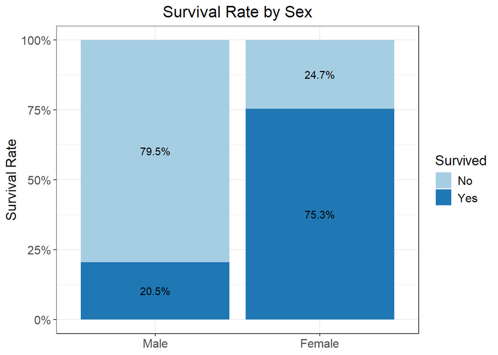

```r
survival_rate_sex %>%
  ggplot(aes(x = Sex, y = SurvivalRate, fill = Survived)) +
  geom_bar(stat = "identity", position = "fill") +     # Stack and scale to 100%
  geom_text(aes(label = scales::percent(SurvivalRate)),  # Display percentage labels
  position = position_fill(vjust = 0.5)) +
  labs(x = NULL, y = "Survival Rate", title = "Survival Rate by Sex") +
  scale_y_continuous(labels = scales::percent)    # Y-axis in percentages
```

**Lollipop Chart**

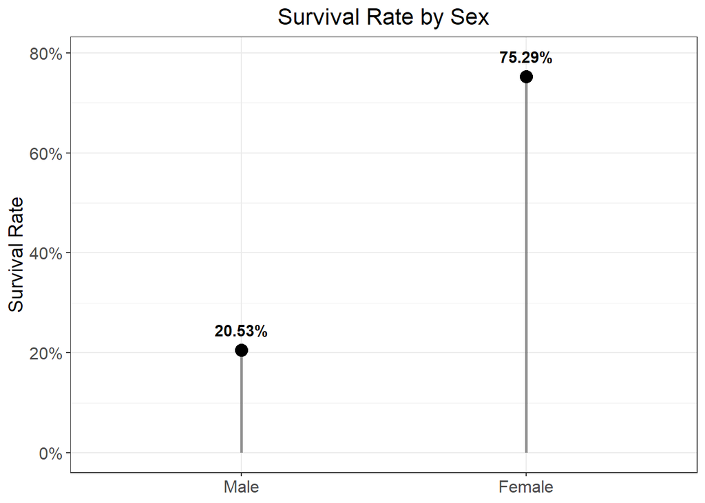

```r
survival_rate_sex %>%
  filter(Survived == "Yes") %>%
  ggplot(aes(x = Sex, y = SurvivalRate)) +
  geom_point(size = 4) +
  geom_segment(aes(xend = Sex, yend = 0),
               linewidth = 1, alpha = 0.4, color = "black") +
  geom_text(aes(label = paste0(round(SurvivalRate*100, 2),"%")),
            nudge_y = 0.04, size = 4, fontface = "bold") +
  labs(x = NULL, y = "Survival Rate", title = "Survival Rate by Sex") +
  scale_y_continuous(labels = scales::percent) +
  guides(fill = "none")
```

## 2.2 Proportion Test

```r
prop.test(x = survival_rate_sex$Freq[survival_rate_sex$Survived == "Yes"],
n = survival_rate_sex$Total[survival_rate_sex$Survived == "Yes"],
alternative = "less")
```

```
    2-sample test for equality of proportions with continuity correction

data:  survival_rate_sex$Freq[survival_rate_sex$Survived == "Yes"] out of survival_rate_sex$Total[survival_rate_sex$Survived == "Yes"]
X-squared = 202.87, df = 1, p-value < 2.2e-16
alternative hypothesis: less
95 percent confidence interval:
 -1.0000000 -0.4905463
sample estimates:
   prop 1    prop 2
0.2052980 0.7528958
```

**Findings**

The survival rate for males is lower than females.

## 2.3 Association between Gender and Survival

**Problem Statement:** Perform a chi-square test to determine if there is a significant association between gender (Sex) and survival.

```r
table(df$Sex, df$Survived)
```

```
          No Yes
  Male   360  93
  Female  64 195
```

```r
chisq.test(df$Sex, df$Survived, correct = FALSE)
```

```
    Pearson's Chi-squared test

data:  df$Sex and df$Survived
X-squared = 205.14, df = 1, p-value < 2.2e-16
```

```r
# Alternatively
chisq.test(table(df$Sex, df$Survived), correct = FALSE)
```

```
    Pearson's Chi-squared test

data:  table(df$Sex, df$Survived)
X-squared = 205.14, df = 1, p-value < 2.2e-16
```

**Findings**

SInce the p-value is less than 0.05, it can concluded that there is a significant association between gender and survival.

# 3 Survival Rate by Passenger Class

**Problem Statement:** Investigate the relationship between passenger class (Pclass) and survival.

```r
survival_rate_pclass <- df %>%
  group_by(Pclass, Survived) %>%
  summarise(Freq = n(), .groups = "drop") %>%
  group_by(Pclass) %>%
  mutate(Total = sum(Freq),
         SurvivalRate = Freq/Total)
survival_rate_pclass
```

| Pclass | Survived | Freq | Total | SurvivalRate |
| --- | --- | --- | --- | --- |
| 1st | No | 64 | 184 | 0.3478261 |
| 1st | Yes | 120 | 184 | 0.6521739 |
| 2nd | No | 90 | 173 | 0.5202312 |
| 2nd | Yes | 83 | 173 | 0.4797688 |
| 3rd | No | 270 | 355 | 0.7605634 |
| 3rd | Yes | 85 | 355 | 0.2394366 |

## 3.1 Visualization

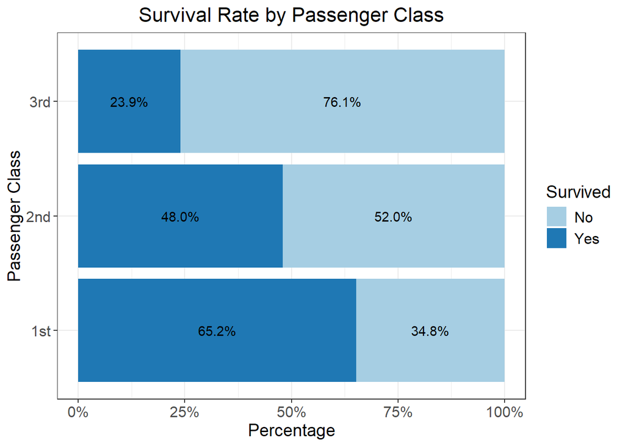

```r
survival_rate_pclass %>%
  ggplot(aes(x = Pclass, y = Freq, fill = Survived)) +
  geom_bar(stat = "identity", position = "fill") +
  geom_text(aes(label = scales::percent(SurvivalRate)),
            position = position_fill(vjust = 0.5)) +
  scale_y_continuous(labels = scales::percent) +
  labs(x = "Passenger Class", y = "Percentage", fill = "Survived",
       title = "Survival Rate by Passenger Class") +
  coord_flip()
```

## 3.2 Pairwise Proportion Test with Bonferroni Correction

```r
pairwise.prop.test(x = survival_rate_pclass$Freq[survival_rate_pclass$Survived == "Yes"],
                   n = survival_rate_pclass$Total[survival_rate_pclass$Survived == "Yes"],
                   p.adjust.method = "bonferroni")
```

```
    Pairwise comparisons using Pairwise comparison of proportions

data:  survival_rate_pclass$Freq[survival_rate_pclass$Survived == "Yes"] out of survival_rate_pclass$Total[survival_rate_pclass$Survived == "Yes"]

  1       2
2 0.0044  -
3 < 2e-16 1.4e-07

P value adjustment method: bonferroni
```

# 4 Survival Rate by Age

**Problem statement:** Analyze the age distribution of passengers to see average age of survivors and deaths.

```r
df %>%
  group_by(Survived) %>%
  summarise(`Average Age` = mean(Age, na.rm = TRUE))
```

| Survived | Average Age |
| --- | --- |
| No | 30.62618 |
| Yes | 28.19330 |

**Note**

Average age of survived passengers is 28.2 years and average age of passengers who did not survive is 30.6 years.0

## 4.1 Visualization

**Boxplot**

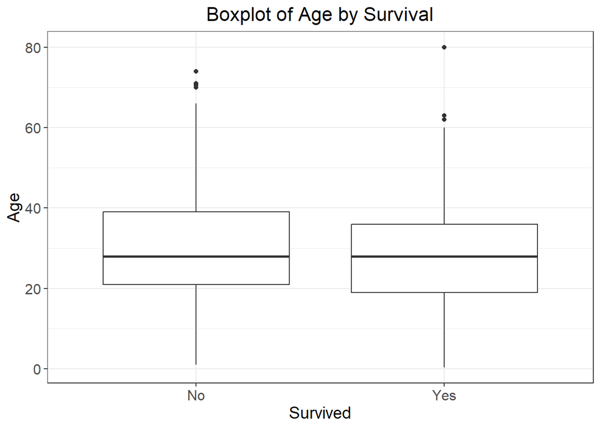

```r
df %>%
  ggplot(aes(x = Survived, y = Age)) +
  geom_boxplot() +
  labs(x = "Survived", y = "Age", title = "Boxplot of Age by Survival")
```

**Density Plot**

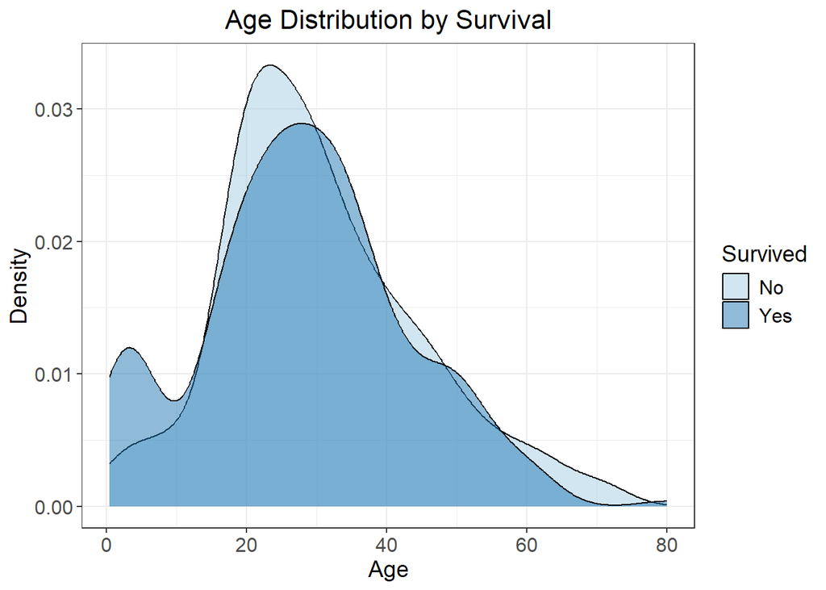

```r
df %>%
  ggplot(aes(fill = Survived, x = Age)) +
  geom_density(alpha = 0.5) +
  labs(x = "Age", y = "Density", fill = "Survived",
title = "Age Distribution by Survival")
```

## 4.2 Two-sample t-test

```r
t.test(Age ~ Survived, data = df)
```

```
    Welch Two Sample t-test

data:  Age by Survived
t = 2.1845, df = 596.68, p-value = 0.02931
alternative hypothesis: true difference in means between group No and group Yes is not equal to 0
95 percent confidence interval:
 0.2456156 4.6201457
sample estimates:
 mean in group No mean in group Yes
         30.62618          28.19330
```

# 5 Survival Rate by Family Size

**Problem Statement:** Visually analyze how family size affects the likelihood of survival.

```r
survival_rate_family_size <- df %>%
  group_by(FamilySize) %>%
  summarise(Survived = sum(Survived=="Yes"),
            Total = n()) %>%
  mutate(SurvivalRate = Survived/Total)
survival_rate_family_size
```

| FamilySize | Survived | Total | SurvivalRate |
| --- | --- | --- | --- |
| 1 | 128 | 402 | 0.3184080 |
| 2 | 76 | 139 | 0.5467626 |
| 3 | 53 | 93 | 0.5698925 |
| 4 | 21 | 27 | 0.7777778 |
| 5 | 3 | 11 | 0.2727273 |
| 6 | 3 | 22 | 0.1363636 |
| 7 | 4 | 12 | 0.3333333 |
| 8 | 0 | 6 | 0.0000000 |

## 5.1 Visualization

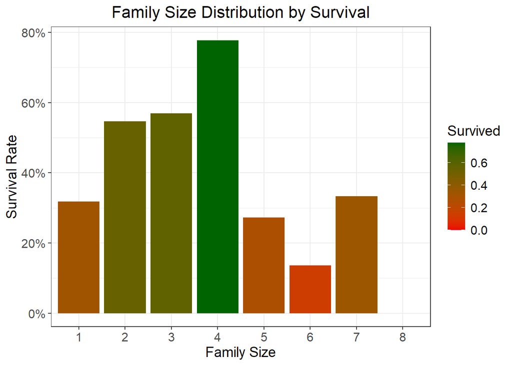

```r
survival_rate_family_size %>%
  ggplot(aes(x = as.factor(FamilySize), y = SurvivalRate, fill = SurvivalRate)) +
  geom_col() +
  labs(x = "Family Size", y = "Survival Rate", fill = "Survived",
title = "Family Size Distribution by Survival") +
  scale_fill_gradient(low = "red2", high = "darkgreen") +
  scale_y_continuous(labels = scales::percent)
```

## 5.2 Logistic Regression

```r
fit <- glm(Survived ~ as.factor(FamilySize), data = df, family = binomial(link = "logit"))
broom::tidy(fit, exponentiate = TRUE)
```

| term | estimate | std.error | statistic | p.value |
| --- | --- | --- | --- | --- |
| (Intercept) | 0.4671533 | 0.1070614 | -7.1089872 | 0.0000000 |
| as.factor(FamilySize)2 | 2.5823413 | 0.2012288 | 4.7145154 | 0.0000024 |
| as.factor(FamilySize)3 | 2.8363281 | 0.2352234 | 4.4320004 | 0.0000093 |
| as.factor(FamilySize)4 | 7.4921875 | 0.4751293 | 4.2385532 | 0.0000225 |
| as.factor(FamilySize)5 | 0.8027344 | 0.6854163 | -0.3205810 | 0.7485280 |
| as.factor(FamilySize)6 | 0.3379934 | 0.6304182 | -1.7206498 | 0.0853144 |
| as.factor(FamilySize)7 | 1.0703125 | 0.6216608 | 0.1093050 | 0.9129605 |
| as.factor(FamilySize)8 | 0.0000004 | 594.1635642 | -0.0249173 | 0.9801209 |

# 6 Visually Inspecting Age Distribution by Pclass and Gender

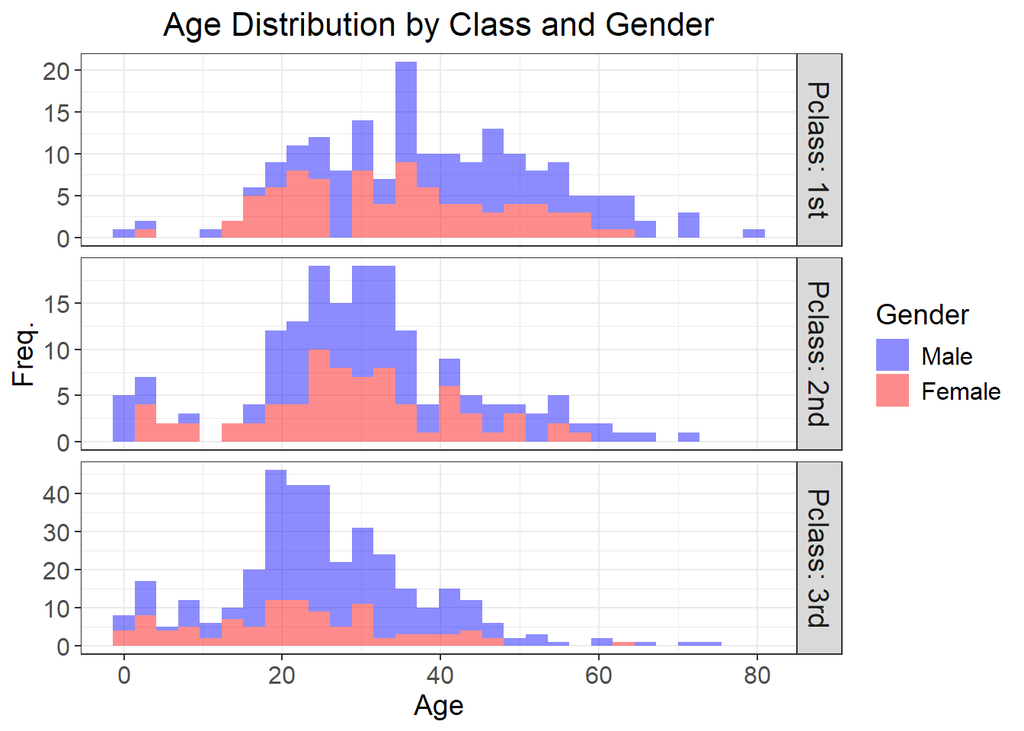

```r
df %>%
  ggplot(aes(x = Age, fill = Sex)) +
  geom_histogram(alpha = 0.45, bins = 30) +
  facet_grid(Pclass~., labeller = label_both, scales = "free_y") +
  scale_fill_manual(values = c("blue", "red")) +
  labs(x = "Age", y = "Freq.", fill = "Gender",
       title = "Age Distribution by Class and Gender")
```

# 7 Survival Rate by Age Group

**Problem Statement:** I’ve already investigated if there is any relationship between age and survival rate. But this time I have grouped the passengers by age and see the difference in survival rate.

```r
survival_rate_age_group <- df %>%
  mutate(AgeGroup = ifelse(Age < 18, "Children", ifelse(Age < 65, "Adults", "Elderly"))) %>%
  group_by(AgeGroup) %>%
  summarise(Survived = sum(Survived=="Yes"),
            Total = n(),
            SurvivalRate = Survived/Total)
survival_rate_age_group
```

| AgeGroup | Survived | Total | SurvivalRate |
| --- | --- | --- | --- |
| Adults | 226 | 588 | 0.3843537 |
| Children | 61 | 113 | 0.5398230 |
| Elderly | 1 | 11 | 0.0909091 |

## 7.1 Visualization

**Manually Ordered Barplot**

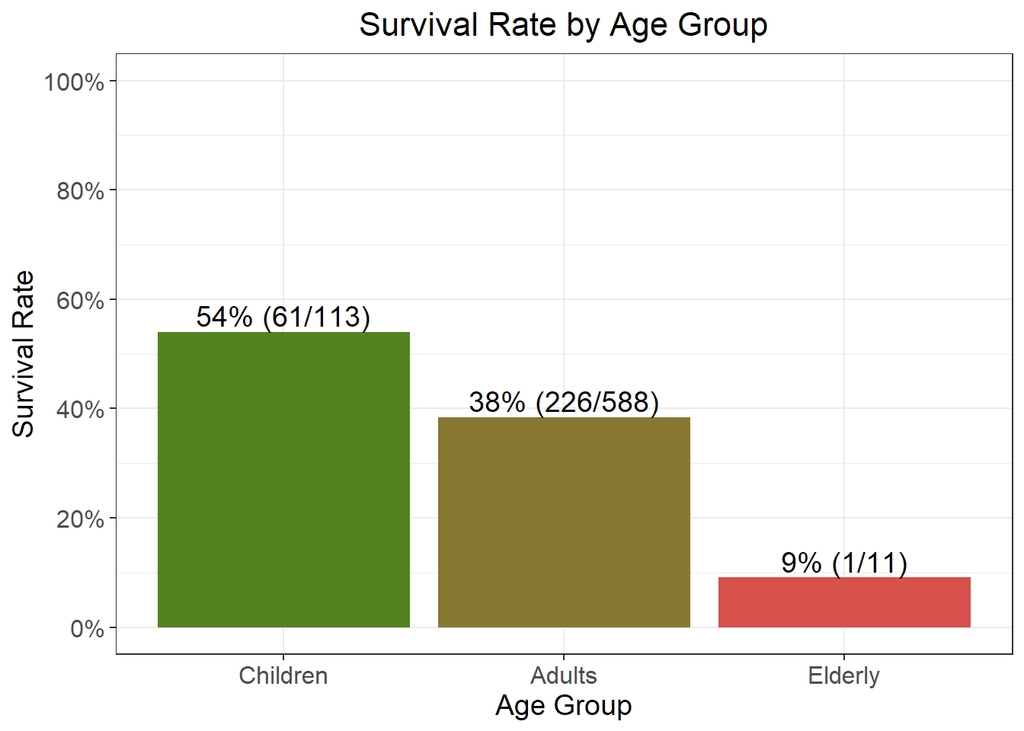

```r
survival_rate_age_group %>%
  ggplot(aes(x = AgeGroup, y = SurvivalRate, fill = SurvivalRate)) +
  geom_col() +
  geom_text(aes(label = paste0(scales::percent(SurvivalRate), " (", Survived,"/",Total,")")),
            nudge_y = 0.03, size = 5) +
  labs(x = "Age Group", y = "Survival Rate", fill = "Age Group",
       title = "Survival Rate by Age Group") +
  scale_fill_gradient(low = "#d7504b", high = "#548220") +
  scale_y_continuous(labels = scales::percent, limits = c(0, 1), breaks = seq(0, 1, 0.2)) +
  scale_x_discrete(limits = c("Children", "Adults", "Elderly")) +    # manually reposition the bars
  guides(fill = "none")
```

**Automatically Arranged Barplot**

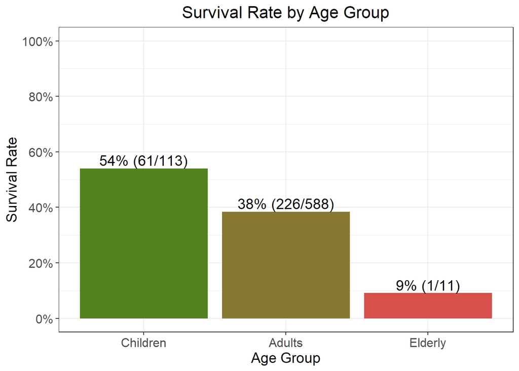

```r
survival_rate_age_group %>%
  ggplot(aes(x = reorder(AgeGroup, -SurvivalRate),    # arrange the bars from highest to lowest
             y = SurvivalRate, fill = SurvivalRate)) +
  geom_col() +
  geom_text(aes(label = paste0(scales::percent(SurvivalRate), " (", Survived,"/",Total,")")),
            nudge_y = 0.03, size = 5) +
  labs(x = "Age Group", y = "Survival Rate", fill = "Age Group",
       title = "Survival Rate by Age Group") +
  scale_fill_gradient(low = "#d7504b", high = "#548220") +
  scale_y_continuous(labels = scales::percent, limits = c(0, 1), breaks = seq(0, 1, 0.2)) +
  guides(fill = "none")
```

**Findings**

The survival rate of children is higher than that of adults and elderlies.